# Student Scores

## Description of Dataset

This dataset is of student achievement in secondary education of two Portuguese schools. The dataset is available on kaggle from [this link](https://www.kaggle.com/larsen0966/student-performance-data-set). The data is originally from Paulo Cortez, University of Minho, and available on [this link](http://www3.dsi.uminho.pt/pcortez). </br>

The data includes demographic information about students (such as gender, age, and adress), social information (such as number of family members, parents status, together or apart, romantic relationship of student, in a relationship or not) as well as some information about personal habits (such as how much free time do they have, how much time do they study, and how frequently do they go out), and most importantly academic information about the students, the academic information comprises of the grades in the Portuguese language over three academic periods, and one other feature; the number of absence days of students over the period of the study. </br>

The features mentioned were collected by using school reports and questionnaires. The data is intended to be used in machine learning appluications to predict the grade of the third period given knowledge of the rest of the demographic, social, and personal features in the data, as well as the grades of the students in the first two periods. </br>

I found this dataset very interesting to investigate as we can not only use it in its intended context, but we also can learn more about different non-academic factors which might affect students performance so we can ultimately suggest how we can enhance students well being and performance. </br>

All features in the dataset:

| Variable | Description | Variable Taxonomy (Type) |
| --- | --- | --- |
| school | student's school (binary: 'GP' - Gabriel Pereira or 'MS' - Mousinho da Silveira) | Categorical - Nominal |
| sex | student's sex (binary: 'F' - female or 'M' - male) | Categorical - Nominal |
| age | student's age (numeric: from 15 to 22) | Quantitave- Discrete - Ratio |
| address | student's home address type (binary: 'U' - urban or 'R' - rural) | Categorical - Nominal |
| famsize | family size (binary: 'LE3' - less or equal to 3 or 'GT3' - greater than 3) | Categorical - Ordinal |
| Pstatus | parent's cohabitation status (binary: 'T' - living together or 'A' - apart) | Categorical - Nominal |
| Medu | mother's education (numeric: 0 - none, 1 - primary education (4th grade), 2 - 5th to 9th grade, 3 - secondary education or 4 - higher education) | Categorical - Ordinal |
| Fedu | father's education (numeric: 0 - none, 1 - primary education (4th grade), 2 - 5th to 9th grade, 3 - secondary education or 4 - higher education) | Categorical - Ordinal |
| Mjob | mother's job (nominal: 'teacher', 'health' care related, civil 'services' (e.g. administrative or police), 'at_home' or 'other') | Categorical - Nominal |
| Fjob | father's job (nominal: 'teacher', 'health' care related, civil 'services' (e.g. administrative or police), 'at_home' or 'other') | Categorical - Nominal |
| reason | reason to choose this school (nominal: close to 'home', school 'reputation', 'course' preference or 'other') | Categorical - Nominal |
| guardian | student's guardian (nominal: 'mother', 'father' or 'other') | Categorical - Nominal |
| traveltime | home to school travel time (numeric: 1 - <15 min., 2 - 15 to 30 min., 3 - 30 min. to 1 hour, or 4 - >1 hour) | Categorical - Ordinal |
| studytime | weekly study time (numeric: 1 - <2 hours, 2 - 2 to 5 hours, 3 - 5 to 10 hours, or 4 - >10 hours) | Categorical - Ordinal |
| failures | number of past class failures (numeric: n if 1<=n<3, else 4) | Categorical - Ordinal |
| schoolsup | extra educational support (binary: yes or no) | Categorical - Nominal |
| famsup | family educational support (binary: yes or no) | Categorical - Nominal |
| paid | extra paid classes within the course subject (Math or Portuguese) (binary: yes or no) | Categorical - Nominal |
| activities | extra-curricular activities (binary: yes or no) | Categorical - Nominal |
| nursery | attended nursery school (binary: yes or no) | Categorical - Nominal |
| higher | wants to take higher education (binary: yes or no) | Categorical - Nominal |
| internet | Internet access at home (binary: yes or no) | Categorical - Nominal |
| romantic | with a romantic relationship (binary: yes or no) | Categorical - Nominal |
| famrel | quality of family relationships (numeric: from 1 - very bad to 5 - excellent) | Categorical - Ordinal |
| freetime | free time after school (numeric: from 1 - very low to 5 - very high) | Categorical - Ordinal |
| goout | going out with friends (numeric: from 1 - very low to 5 - very high) | Categorical - Ordinal |
| Dalc | workday alcohol consumption (numeric: from 1 - very low to 5 - very high) | Categorical - Ordinal |
| Walc | weekend alcohol consumption (numeric: from 1 - very low to 5 - very high) | Categorical - Ordinal |
| health | current health status (numeric: from 1 - very bad to 5 - very good) | Categorical - Ordinal |
| absences | number of school absences (numeric: from 0 to 93) | Quantitave- Discrete - Ratio |
| G1 | first period grade (numeric: from 0 to 20) | Quantitave- Discrete - Ratio |
| G2 | second period grade (numeric: from 0 to 20) | Quantitave- Discrete - Ratio |
| G3 | final grade (numeric: from 0 to 20, output target) | Quantitave- Discrete - Ratio |

### Some notes on the features

1. *I hope you excuse my pun `Variable Taxonomy`. :"D There are different ways to classify different variables we have come across in this course, so cascading them one after another feels pretty much like.. taxonomy.*
2. Although, generally speaking, the age is a continous variable, I here treat as a discrete variable because only integer value ages are recorded. And hence it will make more sense to treat it as such for the porpuse of our visualizations.
3. While letter grades might be considered ordinal variables, I find the numeric grades in this context better dealt with as quantiative features, not just for the obvious reason that they are numeric values and that they can be meaninfully added and have a meaningful zero point, but also because the values are too many to be considered categorical.
4. I found variable names are handy and easy to remember, hence I won't change any. </br>

### The main features of interest in the dataset

I'm most interested in finding out if theres is any relation between the grades and one, or a collection of of the features present in the dataset.

### My expectations for what features of the dataset will help support my investigation into the features of interest

Firstly, I expect that absences will have a great impact on students performance, maybe at least for students who don't take extra paid classes. Otherwise we can make the conclusion that the educational system implented in the schools where the data is collected is not effective at all.</br>

Secondly, I expect a combination of social factors to play a role in determinging the students' performance, some the features concerning family size, emotional environment of the student (represented by romantic relationship and family status, I will consider them to be an indicator for the emotional environment), and their educational level.</br>

Finally, I think some of personal factors play an important role as well, whether the students want to persue higher education, free time, study time, and frequency of going out.

## Preliminary Wrangling

This document throughly explores the features of the desribed dataset, in order to find out any interesting relations or information the dataset can suggest about the collected data and whether there is a relation between academic performance and any of the other features.

```python
# import all packages and set plots to be embedded inline
import numpy as np
import pandas as pd
import matplotlib.pyplot as plt
import seaborn as sb
import matplotlib as mpl

%matplotlib inline
```

```python
# load in the dataset into a pandas dataframe
students = pd.read_csv('student-por.csv')
```

```python
# view first 10 rows to take an overview of the data
students.head(10)
```

|  | school | sex | age | address | famsize | Pstatus | Medu | Fedu | Mjob | Fjob | ... | famrel | freetime | goout | Dalc | Walc | health | absences | G1 | G2 | G3 |
| --- | --- | --- | --- | --- | --- | --- | --- | --- | --- | --- | --- | --- | --- | --- | --- | --- | --- | --- | --- | --- | --- |
| 0 | GP | F | 18 | U | GT3 | A | 4 | 4 | at_home | teacher | ... | 4 | 3 | 4 | 1 | 1 | 3 | 4 | 0 | 11 | 11 |
| 1 | GP | F | 17 | U | GT3 | T | 1 | 1 | at_home | other | ... | 5 | 3 | 3 | 1 | 1 | 3 | 2 | 9 | 11 | 11 |
| 2 | GP | F | 15 | U | LE3 | T | 1 | 1 | at_home | other | ... | 4 | 3 | 2 | 2 | 3 | 3 | 6 | 12 | 13 | 12 |
| 3 | GP | F | 15 | U | GT3 | T | 4 | 2 | health | services | ... | 3 | 2 | 2 | 1 | 1 | 5 | 0 | 14 | 14 | 14 |
| 4 | GP | F | 16 | U | GT3 | T | 3 | 3 | other | other | ... | 4 | 3 | 2 | 1 | 2 | 5 | 0 | 11 | 13 | 13 |
| 5 | GP | M | 16 | U | LE3 | T | 4 | 3 | services | other | ... | 5 | 4 | 2 | 1 | 2 | 5 | 6 | 12 | 12 | 13 |
| 6 | GP | M | 16 | U | LE3 | T | 2 | 2 | other | other | ... | 4 | 4 | 4 | 1 | 1 | 3 | 0 | 13 | 12 | 13 |
| 7 | GP | F | 17 | U | GT3 | A | 4 | 4 | other | teacher | ... | 4 | 1 | 4 | 1 | 1 | 1 | 2 | 10 | 13 | 13 |
| 8 | GP | M | 15 | U | LE3 | A | 3 | 2 | services | other | ... | 4 | 2 | 2 | 1 | 1 | 1 | 0 | 15 | 16 | 17 |
| 9 | GP | M | 15 | U | GT3 | T | 3 | 4 | other | other | ... | 5 | 5 | 1 | 1 | 1 | 5 | 0 | 12 | 12 | 13 |

10 rows × 33 columns

```python
# high-level overview of data shape and composition
print(students.shape)
print(students.dtypes)
```

```
(649, 33)
school        object
sex           object
age            int64
address       object
famsize       object
Pstatus       object
Medu           int64
Fedu           int64
Mjob          object
Fjob          object
reason        object
guardian      object
traveltime     int64
studytime      int64
failures       int64
schoolsup     object
famsup        object
paid          object
activities    object
nursery       object
higher        object
internet      object
romantic      object
famrel         int64
freetime       int64
goout          int64
Dalc           int64
Walc           int64
health         int64
absences       int64
G1             int64
G2             int64
G3             int64
dtype: object
```

```python
# make sure all data is complete
students.isnull().sum().sum()
```

```
0
```

```python
# further investigating which variables have incomplete entries
students.isnull().sum()
```

```
school        0
sex           0
age           0
address       0
famsize       0
Pstatus       0
Medu          0
Fedu          0
Mjob          0
Fjob          0
reason        0
guardian      0
traveltime    0
studytime     0
failures      0
schoolsup     0
famsup        0
paid          0
activities    0
nursery       0
higher        0
internet      0
romantic      0
famrel        0
freetime      0
goout         0
Dalc          0
Walc          0
health        0
absences      0
G1            0
G2            0
G3            0
dtype: int64
```

```python
# after consulting data source I did not find useful info on
# what might causes the problem, so I decided to drop this feature
students = students.drop(columns = ['failures'])
```

[output not shown]

[output not shown]

```python
# dividing features into numerical and categorical features so we can more easily and efficiently explore them
numeric_vars = np.array(['age', 'absences', 'G1', 'G2', 'G3'], dtype=object)
categoric_vars = students.columns.values
for var in numeric_vars:
    categoric_vars = np.delete(categoric_vars, np.where(categoric_vars == var))
```

```python
# make sure they are set right
print(numeric_vars)
print(categoric_vars)
```

```
['age' 'absences' 'G1' 'G2' 'G3']
['school' 'sex' 'address' 'famsize' 'Pstatus' 'Medu' 'Fedu' 'Mjob' 'Fjob'
 'reason' 'guardian' 'traveltime' 'studytime' 'schoolsup' 'famsup' 'paid'
 'activities' 'nursery' 'higher' 'internet' 'romantic' 'famrel' 'freetime'
 'goout' 'Dalc' 'Walc' 'health']
```

```python
# declare all ordinal categorical variables ordinal to make it easier in visualizations
cl0_4 = [i for i in range(0,5)]
cl1_4 = [i for i in range(1,5)]
cl1_5 = [i for i in range(1,6)]

ordinal_var_dict = {'famsize' : ['LE3', 'GT3'],
                    'Medu' : cl0_4,
                    'Fedu' : cl0_4,
                    'traveltime' : cl1_4,
                    'studytime' : cl1_4,
                    'famrel': cl1_5,
                    'freetime' : cl1_5,
                    'goout' : cl1_5,
                    'Dalc': cl1_5,
                    'Walc': cl1_5,
                    'health': cl1_5}

for var in ordinal_var_dict:
    ordered_var = pd.api.types.CategoricalDtype(ordered = True,
                                                categories = ordinal_var_dict[var])
    students[var] = students[var].astype(ordered_var)
```

```python
print(students.dtypes)
```

```
school          object
sex             object
age              int64
address         object
famsize       category
Pstatus         object
Medu          category
Fedu          category
Mjob            object
Fjob            object
reason          object
guardian        object
traveltime    category
studytime     category
schoolsup       object
famsup          object
paid            object
activities      object
nursery         object
higher          object
internet        object
romantic        object
famrel        category
freetime      category
goout         category
Dalc          category
Walc          category
health        category
absences         int64
G1               int64
G2               int64
G3               int64
dtype: object
```

```python
# descriptive statistics for numeric variables
print(students.describe())
```

```
              age    absences          G1          G2          G3
count  649.000000  649.000000  649.000000  649.000000  649.000000
mean    16.744222    3.659476   11.399076   11.570108   11.906009
std      1.218138    4.640759    2.745265    2.913639    3.230656
min     15.000000    0.000000    0.000000    0.000000    0.000000
25%     16.000000    0.000000   10.000000   10.000000   10.000000
50%     17.000000    2.000000   11.000000   11.000000   12.000000
75%     18.000000    6.000000   13.000000   13.000000   14.000000
max     22.000000   32.000000   19.000000   19.000000   19.000000
```

### Final Notes on The Dataset

There are 649 students in the dataset with 32 features, after removing `failures`. Most variables are categorical and the ordinal ones have been declared so to facilitate exploration. But the most important variables `G1`, `G2`, and `G3` are numeric and so are `age` and `absences`.

## Univariate Exploration

Now that we have performed some wrangling and cleaning on the dataset, and made sure tha the data is ready for exploratory analysis, it's time to begin this process by univariate feature exploration. As most of the variables in this dataset are categorical data, it won't be very interesting to explore each of them alone. As most of them will be presented in bar charts which show the category destibutions, which is very important and essential to understand the dataset, reach sound conclusions, and dig out any insights from it, but just not as interesting as the other parts of data exploration will be. </br>

Grades, asa numeric variables will be most appropriatly viewed using a violin plot,rather than a histogram or a box plot as their ranges are relatively small. This applies to absences as well (the source states they range from 0 to 93). And finally age can be viewed using a histogram of very small bin size.</br>

```python
# set important variables for visualizations
# base color to use throughout
base_color =  sb.color_palette()[0]
# number of students to learn percentage of each class
n_students = students.shape[0]
```

because most of the variables are categorical it more convenient and effecient to create a function to draw them and loop over all categorical variables.

```python
def bar_chart_with_perc_of(var_name, ax = None):
    """""
    Draw bar chart(s) for categorical variables.
    var_name: the name of the variable in the students dataset.
    ax: (optional) if more than one variable is to be plotted pass the plt.axes corresponding to each
    variable.
    """""

    # prepare variable to print percentages atop bars
    var_counts = students[var_name].value_counts().sort_index()
    var_levels = var_counts.index
    # with axes
    if ax:
        sb.countplot(data = students, x = var_name, color = base_color, ax = ax, order = var_levels)
    # without axes
    else:
        sb.countplot(data = students, x = var_name, color = base_color, order = var_levels)


    # put percentages on top of bars
    for i,n in enumerate(var_counts):
        per = np.round(n / n_students * 100, 2)
        txt = '{}%'.format(per)
        if ax:
            ax.text(i, n, txt, ha = 'center', va = 'bottom')
        else:
           plt.text(i, n, txt, fontsize = 16-len(students[var_name].unique()), ha = 'center', va = 'bottom')
```

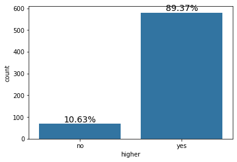

```python
# trying out for one variable
# choosing higher education as I think it importaant and interesting feature
bar_chart_with_perc_of('higher');
```

```python
# enlarge labels and ticks in order to read plots clearly
default_font_size = mpl.rcParams['font.size']
mpl.rcParams['font.size'] = 50

# prepare parameters for the plots
n_figures = len(categoric_vars)
n_fig_in_row = 5
fig_size = 24

# initialize plots
fig, ax = plt.subplots(ncols = n_fig_in_row, nrows = int(np.ceil(n_figures/n_fig_in_row)) , figsize = [ n_fig_in_row * fig_size, int(np.ceil(n_figures/n_fig_in_row)) * fig_size])

# draw for all cateogorical variable
for i, v in enumerate(categoric_vars):
    bar_chart_with_perc_of(v, ax[i//n_fig_in_row, i%n_fig_in_row])

# reset style and font sizes
mpl.rcParams['font.size'] = default_font_size
```

[figure not shown]

The distributions of all variables do not show any problems with the data, hence no further cleaning or fixing is required. Apart from that I don't find any particular aspect of the distributions particularly interesting or promising. Hence I will continue with investigating the rest of the variables before we go on to the more interesting patrs of bivariate and mutlivariate explorations.

Now we procede to explore numeric variables.

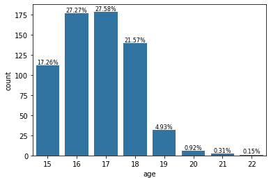

```python
# age distribution
bar_chart_with_perc_of('age')
```

Most of the students are in the age group of 15 to 18 (teenagers) and some few students are of higher ages.

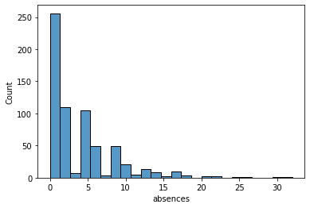

```python
# investigate absences
sb.histplot(data = students, x = 'absences', color = base_color);
```

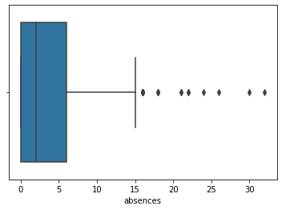

```python
# investigate absences with a box plot
sb.boxplot(data = students, x = 'absences', color = base_color);
```

We can see that number of absence days for most of the students is less than 10. Indeed only outlier values reside in the range greater than 15 days.

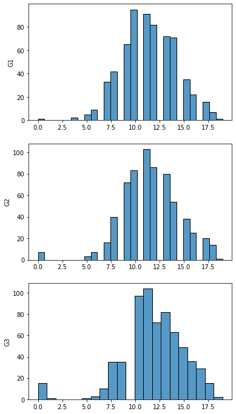

```python
# investigate grades
fig, ax = plt.subplots(nrows = 3, figsize = [6, 12])
grades = ['G1', 'G2', 'G3']
for i, g in enumerate(grades):
    sb.histplot(data = students, x = g, color = base_color, ax = ax[i]);
    ax[i].set(xlabel = '', ylabel = g)
```

The grade distribution does not change in structure from one period to another. The five number summaries of all are close, and the distributions are similar as well.

It is important to check the average grade as well.

```python
# calculate average
grades = ['G1', 'G2', 'G3']
students = students.assign(Gavg = students[grades].mean(1))
```

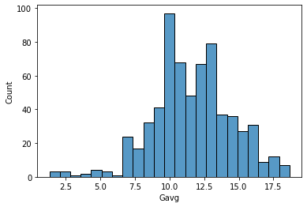

```python
# check average grades
sb.histplot(data = students, x = 'Gavg', color = base_color);
```

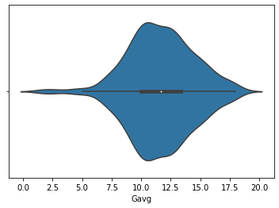

```python
# investigate average grades further by violinplot
sb.violinplot(data = students, x = 'Gavg', color = base_color);
```

The average grade has two near modes. But apart from the small gap right in the middle it has a near normal distribution.

Finally, I think viewing descriptive statistics of numeric variables here once more can help us understand the data more at this point.

```python
# descriptive statistics for numeric variables
print(students.describe())
```

```
              age    absences          G1          G2          G3        Gavg
count  649.000000  649.000000  649.000000  649.000000  649.000000  649.000000
mean    16.744222    3.659476   11.399076   11.570108   11.906009   11.625064
std      1.218138    4.640759    2.745265    2.913639    3.230656    2.833360
min     15.000000    0.000000    0.000000    0.000000    0.000000    1.333333
25%     16.000000    0.000000   10.000000   10.000000   10.000000   10.000000
50%     17.000000    2.000000   11.000000   11.000000   12.000000   11.666667
75%     18.000000    6.000000   13.000000   13.000000   14.000000   13.333333
max     22.000000   32.000000   19.000000   19.000000   19.000000   18.666667
```

Again, we can see that the distributions of the features do not show any queer properties and thus there is no need for any further cleaning or wrangling on the data. </br> And we can mention finally that distribution of grades does not is very close from one period to the next both in distribution and in statistical summaries.</br>

Now that we have throughly investigated each variable alone, it is time to check if there is any correlations trends between different features.</br> We will focus on the potential correlations or trends between the grades and other variables, as the students grades are the ones of interest in our study.

## Bivariate Exploration

I start by examining potential correlation between numerical varaibles. Both using a heat map and using a scatter grid. As a scatter grid can give us more informatino and understanding of data distribution but the correlation coeffecients are more suitable as predictors of the existance of any relations.

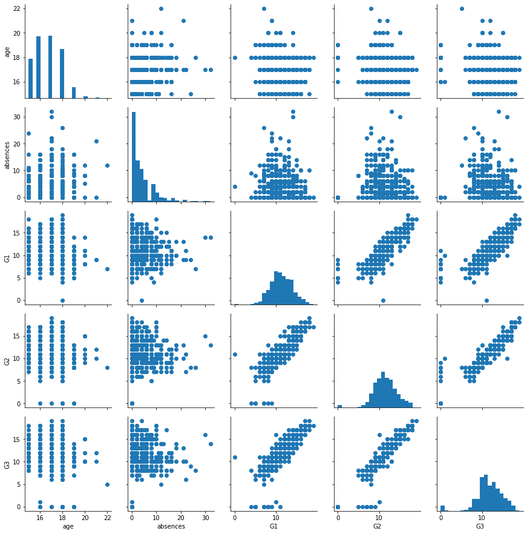

```python
sct_plt = sb.PairGrid(data = students, vars = numeric_vars)
sct_plt = sct_plt.map_diag(plt.hist, bins = 20);
sct_plt.map_offdiag(plt.scatter);
```

The only strong correlations we can see in these scatter plots are between the interest features themselves; the grades of different periods. This makes sense as the performance of a student is not expected to change drastically from one period to another. I was expecting a stronger correlation between absences and grades, as I thought the number of absence days would be an indicator of perfomance. But it did not show that much of effect. </br> We will further investigate correlation cooffecients to make sure of our findings.

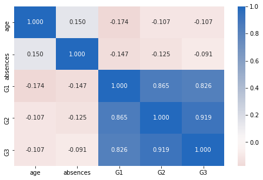

```python
# correlation plot
plt.figure(figsize = [8, 5])
sb.heatmap(students[numeric_vars].corr(), annot = True, fmt = '.3f',
           cmap = 'vlag_r', center = 0)
plt.show()
```

The correlation cooffecients point us in the same direction. There is almost no effect for the numeric variables on the grades. Only grades have strong correlations between one another which makes sense within educational systems as referred earlier.

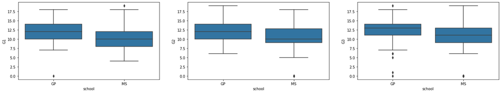

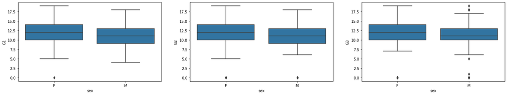

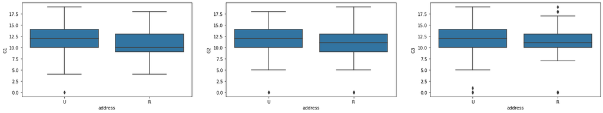

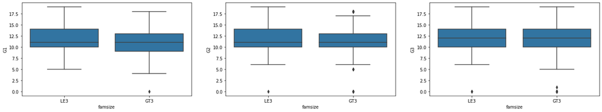

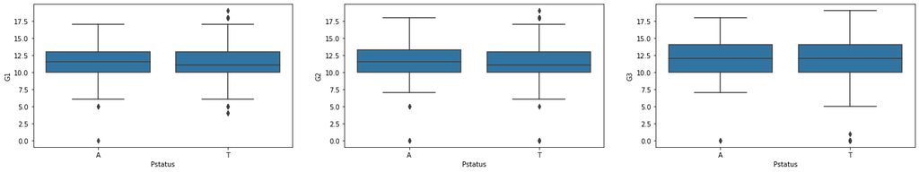

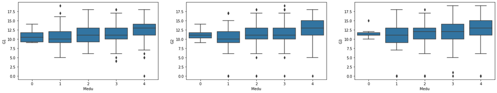

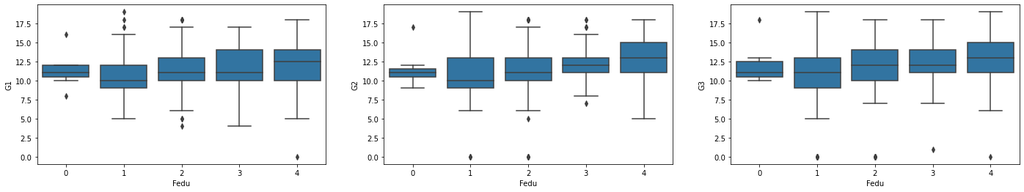

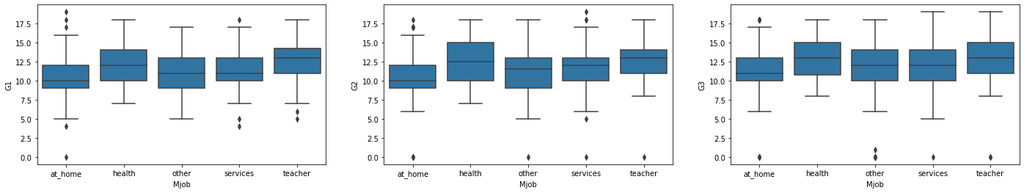

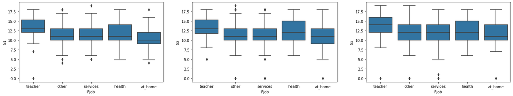

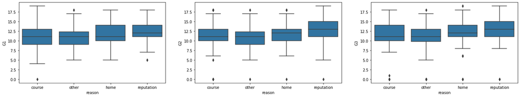

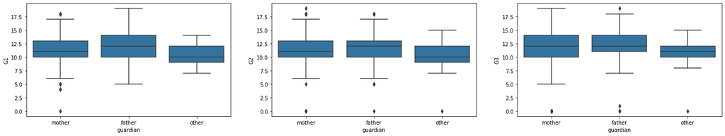

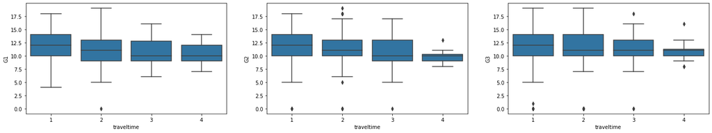

[15 more figures not shown]

```python
# set parameters
grades = ['G1', 'G2', 'G3']
n_fig_in_row = len(grades)
fig_size = 8
for v in categoric_vars:
    fig, ax = plt.subplots(ncols = len(grades), figsize = [24, 4])
    for i, g in enumerate(grades):
        sb.boxplot(data = students, x = v, y = g, ax = ax[i], color = base_color)
```

In nearly all the cases where there is some trend between levels of a varialbe and the grades it is present in grades of all three periods. But I would still like to make sure that this relation exist on average grades. So I will calculate the average and create the same visualizations with respect to only the average grade of a student.